# Principal Components Analysis

```r
library(dimensio)
```

# 1 Do PCA

```r
## Load data
data(iris)
head(iris)
```

```
#>   Sepal.Length Sepal.Width Petal.Length Petal.Width Species
#> 1          5.1         3.5          1.4         0.2  setosa
#> 2          4.9         3.0          1.4         0.2  setosa
#> 3          4.7         3.2          1.3         0.2  setosa
#> 4          4.6         3.1          1.5         0.2  setosa
#> 5          5.0         3.6          1.4         0.2  setosa
#> 6          5.4         3.9          1.7         0.4  setosa
```

```r
## Compute PCA
## (non numeric variables are automatically removed)
X <- pca(iris, center = TRUE, scale = TRUE)
```

```
#> 1 qualitative variable was removed: Species.
```

# 2 Explore the results

**dimensio** provides several methods to extract (`get_*()`) the results:

- `get_data()` returns the original data.
- `get_contributions()` returns the contributions to the definition of the principal dimensions.
- `get_coordinates()` returns the principal or standard coordinates.
- `get_correlations()` returns the correlations between variables and dimensions.
- `get_cos2()` returns the cos<sup>2</sup> values (i.e. the quality of the representation of the points on the factor map).
- `get_eigenvalues()` returns the eigenvalues, the percentages of variance and the cumulative percentages of variance.

The package also allows to quickly visualize (`viz_*()`) the results:

- `biplot()` produces a biplot.
- `screeplot()` produces a scree plot.
- `viz_rows()`/`viz_individuals()` displays row/individual principal coordinates.
- `viz_columns()`/`viz_variables()` displays columns/variable principal coordinates.
- `viz_contributions()` displays (joint) contributions.
- `viz_cos2()` displays (joint) cos<sup>2</sup>.

```r
## Get eigenvalues
get_eigenvalues(X)
```

```
#>    eigenvalues  variance cumulative
#> F1   2.9184978 73.342264   73.34226
#> F2   0.9140305 22.969715   96.31198
#> F3   0.1467569  3.688021  100.00000
```

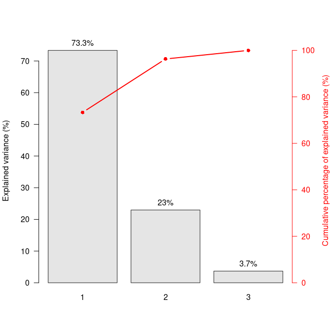

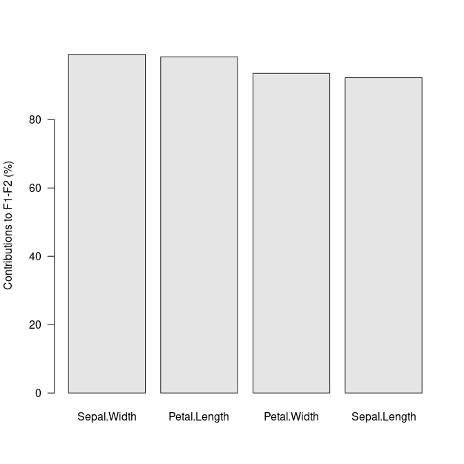

```r
## Scree plot
screeplot(X, cumulative = TRUE)

## Plot variable contributions to the definition of the first two axes
viz_contributions(X, margin = 2, axes = c(1, 2))
```

# 3 PCA biplot

The form biplot favors the representation of the individuals: the distance between the individuals approximates the Euclidean distance between rows. In the form biplot the length of a vector approximates the quality of the representation of the variable.

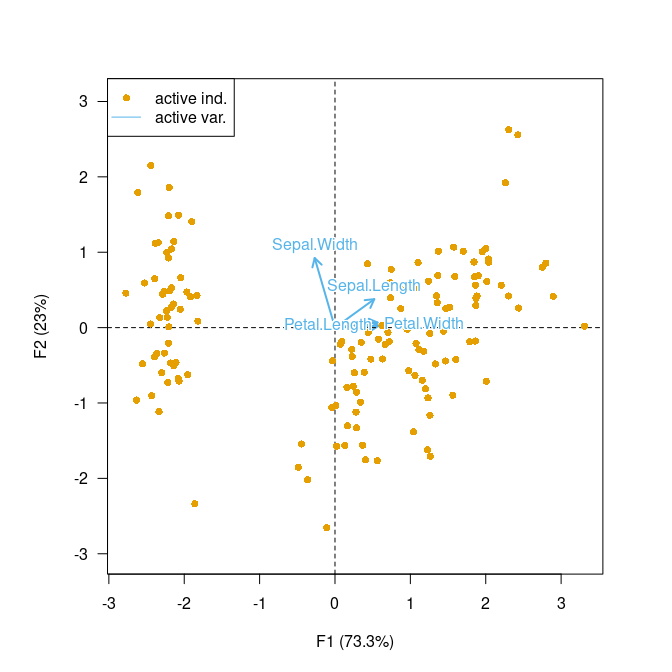

```r
biplot(X, type = "form", label = "variables")
```

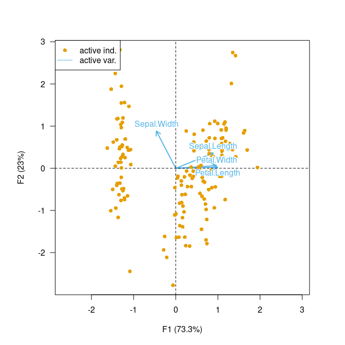

```r
biplot(X, type = "covariance", label = "variables")
```

Biplots have the drawbacks of their advantages: they can quickly become difficult to read as they display a lot of information at once. It may then be preferable to visualize the results for individuals and variables separately.

# 4 Plot PCA loadings

`viz_variables()` depicts the variables by rays emanating from the origin (both their lengths and directions are important to the interpretation).

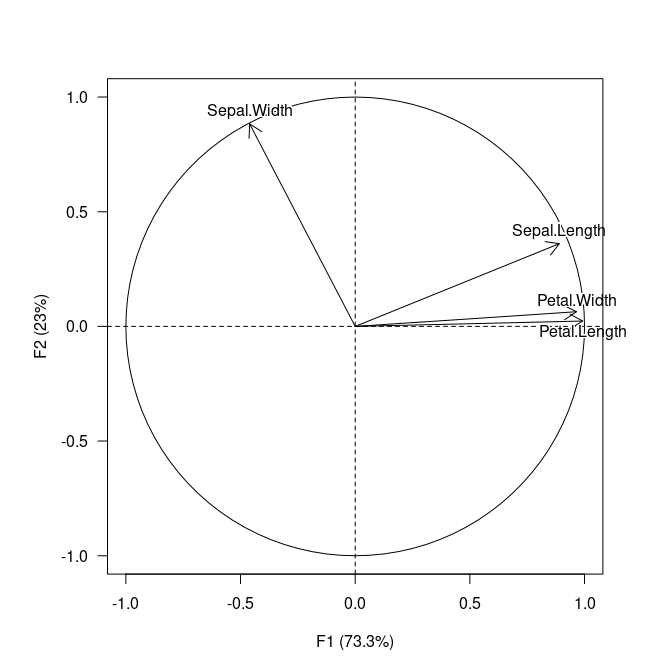

```r
## Plot variables factor map
viz_variables(X)
```

`viz_variables()` allows to highlight additional information by varying different graphical elements (color, transparency, shape and size of symbols…).

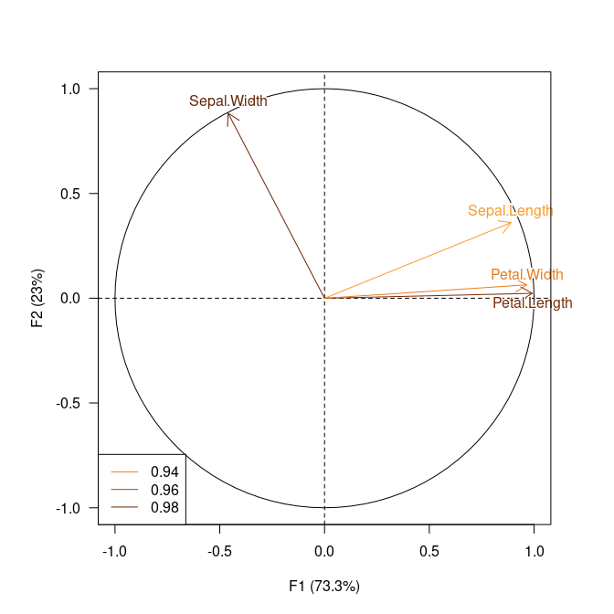

```r
## Highlight cos2
viz_variables(
  x = X,
  highlight = "cos2",
  col = khroma::color("YlOrBr")(4, range = c(0.5, 1)),
  legend = list(x = "bottomleft")
)
```

# 5 Plot PCA scores

`viz_individuals()` allows to display individuals and to highlight additional information.

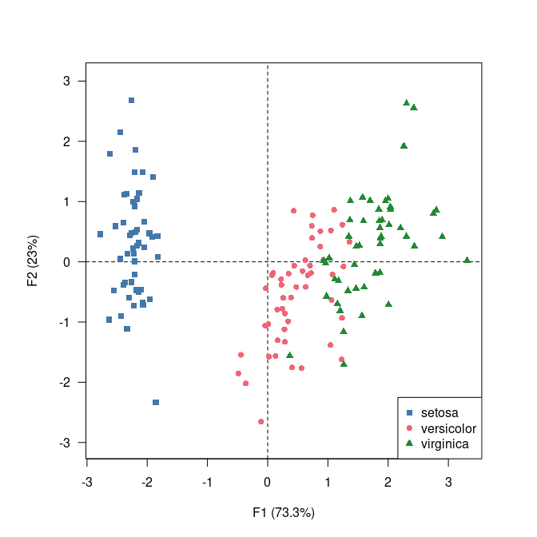

```r
## Plot individuals and color by species
viz_individuals(
  x = X,
  highlight = iris$Species,
  col = khroma::color("bright")(3), # Custom color scale
  pch = c(15, 16, 17), # Custom symbols
  legend = list(x = "bottomright")
)
```

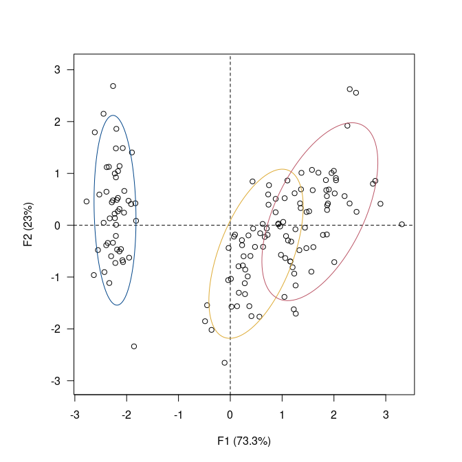

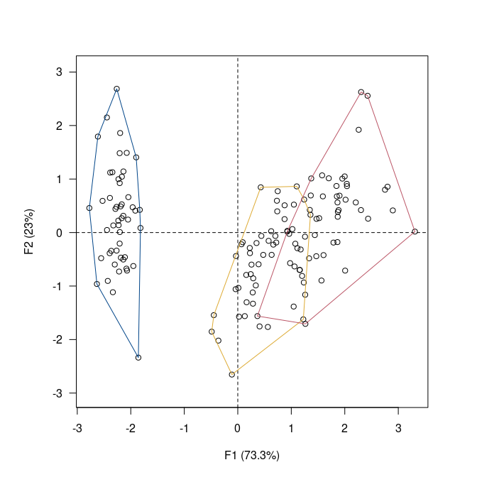

```r
## Add ellipses
viz_individuals(x = X)
viz_tolerance(x = X, group = iris$Species, level = 0.95,
              border = khroma::color("high contrast")(3))

## Add convex hull
viz_individuals(x = X)
viz_hull(x = X, group = iris$Species, level = 0.95,
         border = khroma::color("high contrast")(3))
```

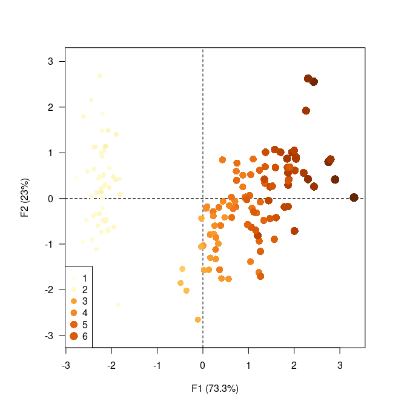

```r
## Highlight petal length
viz_individuals(
  x = X,
  highlight = iris$Petal.Length,
  col = khroma::color("YlOrBr")(12), # Custom color scale
  cex = c(1, 2), # Custom size scale
  pch = 16,
  legend = list(x = "bottomleft")
)
```

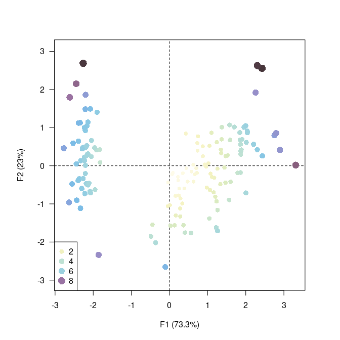

```r
## Highlight contributions
viz_individuals(
  x = X,
  highlight = "contrib",
  col = khroma::color("iridescent")(12), # Custom color scale
  cex = c(1, 2), # Custom size scale
  pch = 16,
  legend = list(x = "bottomleft")
)
```

# 6 Custom plot

If you need more flexibility, the `get_*()` family and the `tidy()` and `augment()` functions allow you to extract the results as data frames and thus build custom graphs with base **graphics** or **ggplot2**.

```r
iris_tidy <- tidy(X, margin = 2)
head(iris_tidy)
```

```
#>          label component supplementary coordinate contribution        cos2
#> 1 Petal.Length        F1         FALSE 0.99155518  33.68793618 0.983181682
#> 2 Petal.Length        F2         FALSE 0.02341519   0.05998389 0.000548271
#> 3 Petal.Length        F3         FALSE 0.05444699   2.01999049 0.002964475
#> 4  Petal.Width        F1         FALSE 0.96497896  31.90629060 0.931184395
#> 5  Petal.Width        F2         FALSE 0.06399985   0.44812296 0.004095980
#> 6  Petal.Width        F3         FALSE 0.24298265  40.23019050 0.059040571
```

```r
iris_augment <- augment(X, margin = 1)
head(iris_augment)
```

```
#>          F1         F2 label supplementary        mass      sum contribution
#> 1 -2.264703  0.4800266     1         FALSE 0.006666667 5.359304     3.572870
#> 2 -2.080961 -0.6741336     2         FALSE 0.006666667 4.784855     3.189904
#> 3 -2.364229 -0.3419080     3         FALSE 0.006666667 5.706480     3.804320
#> 4 -2.299384 -0.5973945     4         FALSE 0.006666667 5.644048     3.762699
#> 5 -2.389842  0.6468354     5         FALSE 0.006666667 6.129742     4.086494
#> 6 -2.075631  1.4891775     6         FALSE 0.006666667 6.525894     4.350596
#>        cos2
#> 1 0.9968578
#> 2 0.9864650
#> 3 0.9995167
#> 4 0.9977577
#> 5 0.9997491
#> 6 0.9998819
```

```r
## Custom plot with ggplot2
ggplot2::ggplot(data = iris_augment) +
  ggplot2::aes(x = F1, y = F2, colour = contribution) +
  ggplot2::geom_vline(xintercept = 0, linewidth = 0.5, linetype = "dashed") +
  ggplot2::geom_hline(yintercept = 0, linewidth = 0.5, linetype = "dashed") +
  ggplot2::geom_point() +
  ggplot2::coord_fixed() + # /!\
  ggplot2::theme_bw() +
  khroma::scale_color_iridescent()
```

[output not shown]

# 7 References